# Rishika Projectf Vehicle Insurace

### STEP12: Customer Loyalty Analysis

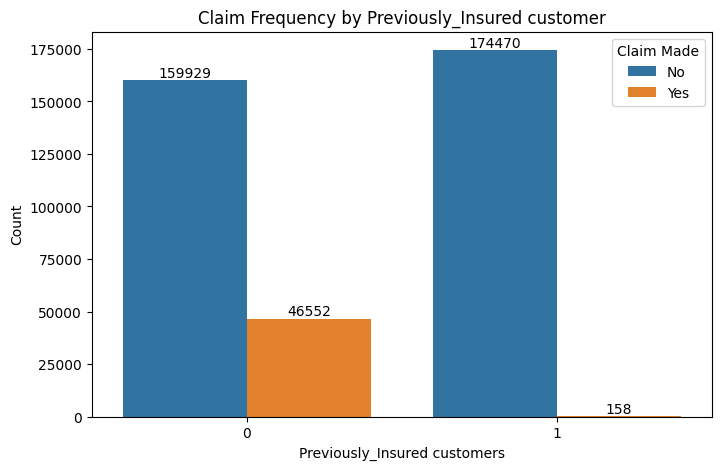

```python
plt.figure(figsize=(8, 5))
ax=sns.countplot(x='Previously_Insured', hue='Response', data=df2)
for bars in ax.containers:
    ax.bar_label(bars)
plt.title('Claim Frequency by Previously_Insured customer')
plt.xlabel('Previously_Insured customers')
plt.ylabel('Count')
plt.legend(title='Claim Made', labels=['No', 'Yes'])
plt.show()
```

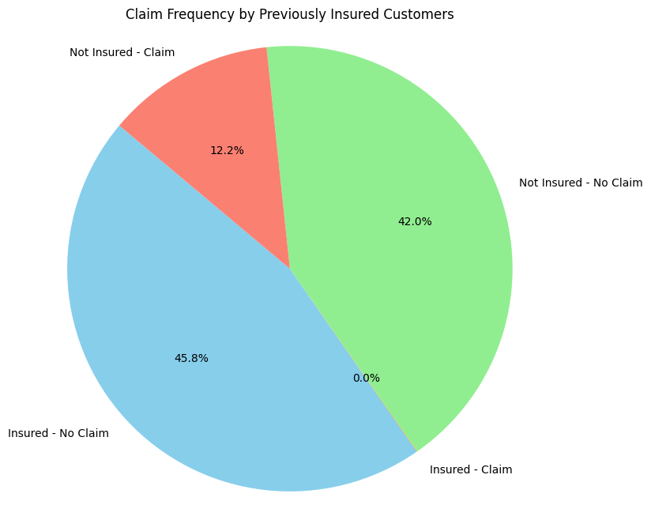

```python
insured_counts = df2[df2['Previously_Insured'] == 1]['Response'].value_counts()
not_insured_counts = df2[df2['Previously_Insured'] == 0]['Response'].value_counts()
# Create labels and sizes
labels = ['Insured - No Claim', 'Insured - Claim', 'Not Insured - No Claim', 'Not Insured - Claim']
sizes = [insured_counts[0], insured_counts[1], not_insured_counts[0], not_insured_counts[1]]
# Plot the pie chart
plt.figure(figsize=(8, 8))
plt.pie(sizes, labels=labels, autopct='%1.1f%%', startangle=140, colors=['skyblue', 'orange', 'lightgreen', 'salmon'])
plt.title('Claim Frequency by Previously Insured Customers')
plt.axis('equal') # Equal aspect ratio ensures the pie is drawn as a circle.
plt.show()
```

### Recommendations:

- For insured customers: Maintain current practices but verify if the 0% claim rate is accurate or reflects underutilization of policies.
- For non-insured customers: Target them with insurance benefits campaigns and analyze the claim-prone segment (12.2%) for tailored products.

### STEP13: Time Analysis

[figure not shown]

```python
plt.figure(figsize=(12, 6))
sns.histplot(data=df2, x='Vintage', hue='Response', kde=True, bins=30)
plt.title('Temporal Patterns in Insurance Claims (Vintage)')
plt.xlabel('Vintage (Days)')
plt.ylabel('Frequency')
plt.legend(title='Response', labels=['No', 'Yes'])
plt.show()
```

### Insights:

- Stable claim patterns over time: The frequency of claims remains relatively consistent across the "vintage" period (0–300 days), with only minor fluctuations.
- Low response for claims: Very few claims are marked "Yes," while the majority are "No," indicating a low claim response rate throughout the period.

# **Conclusion**

Through the EDA of the vehicle insurance dataset, we uncovered actionable insights into policyholder demographics, driving behavior, and insurance claim trends. These insights can be utilized to design data-driven strategies, enhance customer segmentation, and mitigate risks effectively. This analysis provides a foundation for further predictive modeling and decision-making processes within the organization.